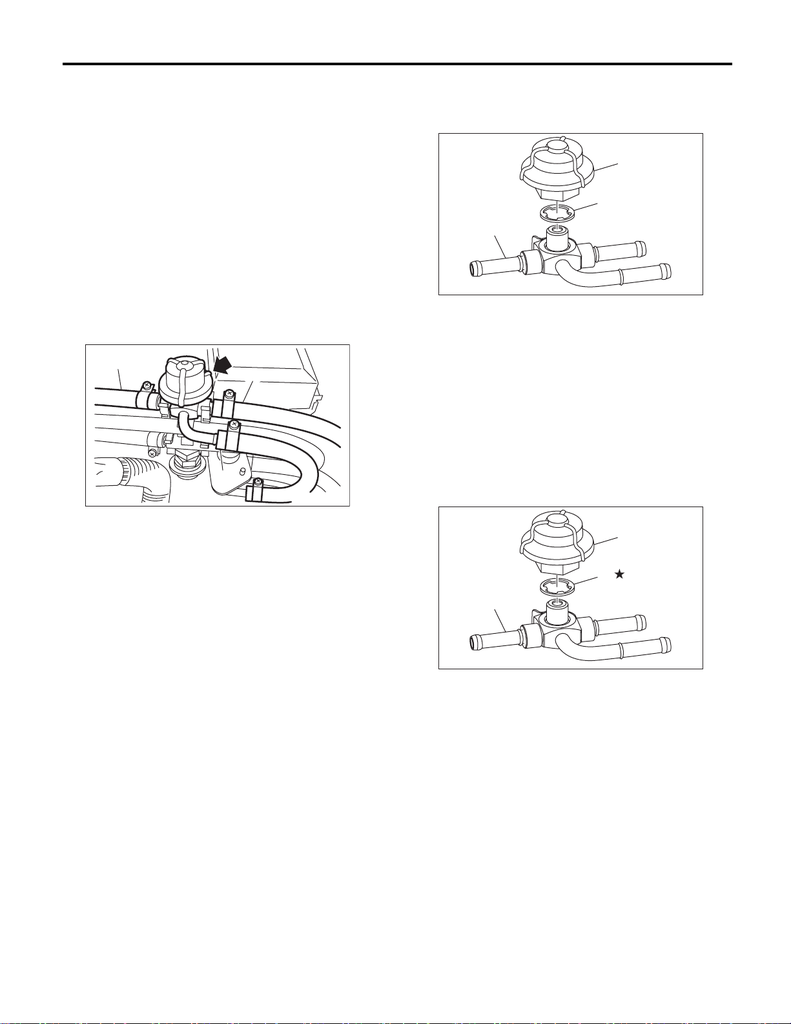

FU(STI)-91

Pulsation Damper Assembly

FUEL INJECTION (FUEL SYSTEMS)

33.Pulsation Damper Assembly

A: REMOVAL

WARNING:

Place “NO OPEN FLAMES” signs near the

working area.

CAUTION:

• Be careful not to spill fuel.

• Catch the fuel from hoses using a container

or cloth.

1) Release the fuel pressure. <Ref. to FU(STI)-64,

RELEASING OF FUEL PRESSURE, PROCE-

DURE, Fuel.>

2) Disconnect the fuel delivery hose (A) and fuel

hose (B) from the pulsation damper assembly, and

remove the pulsation damper assembly.

B: INSTALLATION

Install in the reverse order of removal.

NOTE:

For the information about connecting the fuel deliv-

ery hose and fuel hose, refer to “Fuel Delivery, Re-

turn & Evaporation Lines”. <Ref. to FU(STI)-99,

CONNECTING FUEL DELIVERY HOSE, FUEL

RETURN HOSE AND FUEL HOSE, INSTALLA-

TION, Fuel Delivery, Return and Evaporation

Lines.>

C: DISASSEMBLY

Remove the pulsation damper and fuel pipe gasket

from the fuel by-pass pipe.

D: ASSEMBLY

Install the fuel pipe gasket and pulsation damper to

the fuel by-pass pipe.

NOTE:

Use a new fuel pipe gasket.

Tightening torque:

21.6 N·m (2.2 kgf-m, 15.9 ft-lb)

E: INSPECTION

1) Check that the pulsation damper assembly has

no deformation, cracks or other damages.

2) Check that the fuel delivery hose and fuel hose

have no cracks, damage or loose part.

FU-08482

(A)

(B)

(A)

(A) Fuel by-pass pipe

(B) Pulsation damper

(C) Fuel pipe gasket

(A) Fuel by-pass pipe

(B) Pulsation damper

(C) Fuel pipe gasket

FU-06743

(C)

(B)

(A)

FU-06744

(C)

(B)

(A)